# outcome_damage_amount

## Load packages

```python
%matplotlib inline
import numpy as np
import pandas as pd
import matplotlib as mpl
import matplotlib.pyplot as plt
import seaborn as sns
plt.style.use('seaborn-darkgrid')
```

### Load dataset

```python
df = pd.read_csv('data_cleaned.csv')

# indicate dummy features
df.iloc[:,19:99] = df.iloc[:,19:99].astype('category')
df.info()
```

```
<class 'pandas.core.frame.DataFrame'>
RangeIndex: 4947 entries, 0 to 4946
Data columns (total 99 columns):
 #   Column                  Non-Null Count  Dtype
---  ------                  --------------  -----
 0   income_am               4947 non-null   float64
 1   profit_last_am          4947 non-null   float64
 2   profit_am               4947 non-null   float64
 3   damage_am               4947 non-null   float64
 4   crd_lim_rec             4947 non-null   float64
 5   cab_requests            4947 non-null   int64
 6   bar_no                  4947 non-null   int64
 7   neighbor_income         4947 non-null   float64
 8   age                     4947 non-null   int64
 9   tenure_mts              4947 non-null   int64
```

[output cut: 91 more lines]

```python
df = df.drop(['outcome_damage_inc', 'outcome_profit'], axis=1)
```

```python
# Get the column name you want to move to the last column
feature_name = 'outcome_damage_amount'

# Get a list of column names, excluding the feature to move
other_columns = [col for col in df.columns if col != feature_name]

# Reorder the columns so the feature is at the end
new_columns = other_columns + [feature_name]
df = df[new_columns]
```

## Train test split and standardisation

### Shuffle

```python
from random import Random
df_shuffle = df.sample(frac=1, random_state=123)
```

### Train/test-split

```python
# Import the function
from sklearn.model_selection import train_test_split

# Split of feaures and outcomes
X = df_shuffle.drop(['outcome_damage_amount'],1)
y = df_shuffle['outcome_damage_amount']


# train/split in training and test set
X_train_val, X_test, y_train_val, y_test = train_test_split(X, y, test_size=0.2, random_state=1234)
# train/split in training and validation
X_train, X_val, y_train, y_val = train_test_split(X_train_val, y_train_val, test_size=0.2, random_state=4321)
```

### Standardise

```python
from sklearn.preprocessing import StandardScaler

num_feat = X_train.select_dtypes(include=['int64', 'float64']).columns

scaler = StandardScaler()

# fit the scaler to the training data
scaler.fit(X_train[num_feat])

X_train_stand = X_train.copy()
X_trainval_stand = X_train_val.copy()
X_val_stand = X_val.copy()
X_test_stand = X_test.copy()

# transform the data
X_train_stand[num_feat] = scaler.fit_transform(X_train_stand[num_feat])

X_val_stand[num_feat] = scaler.transform(X_val_stand[num_feat])
X_trainval_stand[num_feat] = scaler.transform(X_trainval_stand[num_feat])

X_test_stand[num_feat] = scaler.transform(X_test_stand[num_feat])
```

# Polynomials - Penalisation

```python
from sklearn.preprocessing import PolynomialFeatures

poly = PolynomialFeatures(degree=1)
X_train_poly = poly.fit_transform(X_train_stand)
X_val_poly = poly.transform(X_val_stand)
X_train_poly.shape
```

```
(3165, 97)
```

prevent polynomial regression to overfit (curse of dimensionality)

```python
from sklearn import linear_model

linreg_lasso1 = linear_model.Lasso()
linreg_lasso1.fit(X_train_poly, y_train)
print('R2: %.3f' % linreg_lasso1.score(X_train_poly, y_train))
print('R2: %.3f' % linreg_lasso1.score(X_val_poly, y_val))
```

```
R2: 0.118
R2: 0.084
```

crossvalidation

```python
from sklearn.model_selection import cross_val_score
from sklearn import linear_model

Alpha = np.logspace(-3,0)
print(Alpha)
cv_scores = []
sd_scores = []
# perform 5-fold cross validation on the  possible values for the radius (bandwidth)

for a in Alpha:
    lasso = linear_model.Lasso(a, max_iter=3000)
    scores = cross_val_score(lasso, X_train_poly, y_train, cv=5)
    cv_scores.append(scores.mean())
    sd_scores.append(np.sqrt(scores.var())/np.sqrt(5))

max_value = max(cv_scores)
max_index = cv_scores.index(max_value)

train = linear_model.Lasso(Alpha[max_index], max_iter=3000)
train.fit(X_train_poly,y_train)
```

```
[0.001      0.0011514  0.00132571 0.00152642 0.00175751 0.00202359
 0.00232995 0.0026827  0.00308884 0.00355648 0.00409492 0.00471487
 0.00542868 0.00625055 0.00719686 0.00828643 0.00954095 0.01098541
 0.01264855 0.01456348 0.01676833 0.01930698 0.02222996 0.02559548
 0.02947052 0.03393222 0.0390694  0.04498433 0.05179475 0.05963623
 0.06866488 0.07906043 0.09102982 0.10481131 0.12067926 0.13894955
 0.15998587 0.184207   0.21209509 0.24420531 0.28117687 0.32374575
 0.37275937 0.42919343 0.49417134 0.5689866  0.65512856 0.75431201
 0.86851137 1.        ]
```

[output not shown]

[output cut: 190 more lines]

```
Lasso(max_iter=3000)
```

```
The optimal alpha is 1.0
The training score of the optimal alpha is 0.11773948315230087
The validation score of the optimal alpha is 0.08554604646402249
```

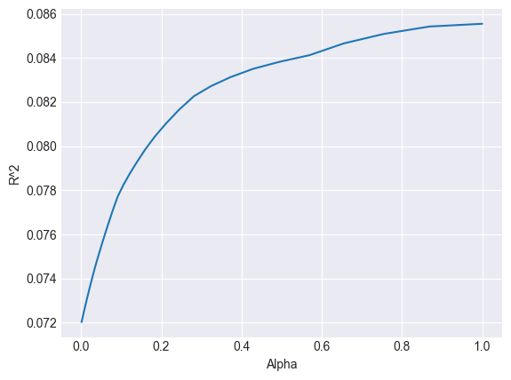

```python
# plotting the best alpha

plt.plot(Alpha, cv_scores)
plt.xlabel('Alpha')
plt.ylabel('R^2')

print('The optimal alpha is', Alpha[max_index])
print('The training score of the optimal alpha is', train.score(X_train_poly,y_train))
print('The validation score of the optimal alpha is', max_value)

plt.show()
```

### Polynomial regression

```python
# Calculate the best degree to use using the average score with cross-validation
from sklearn.pipeline import Pipeline
from sklearn.preprocessing import PolynomialFeatures
from sklearn.model_selection import cross_val_score
from sklearn.linear_model import LinearRegression

avg_scores = [None] * 3
sd_scores = [None] * 3 	  # a degree > 3 will give R^2 in the (-) thousands so we took 3 as the max degree

for i in np.arange(0,3):
    reg_poly = Pipeline([('stand', StandardScaler()),
                  ('poly', PolynomialFeatures(degree=i)),
                  ('linear', LinearRegression(fit_intercept=False))])

    scores = cross_val_score(reg_poly, X_train_poly, y_train, scoring = 'r2', cv=5)

    avg_scores[i] = scores.mean()
    sd_scores[i] = np.sqrt(scores.var())/np.sqrt(5)
    print("Order " + str(i) + ": avg R^2 = " + str(avg_scores[i]))
```

```
Order 0: avg R^2 = -0.00023001399036868265
Order 1: avg R^2 = -1.1955319522934175e+24
Order 2: avg R^2 = -1126.5304307591596
```

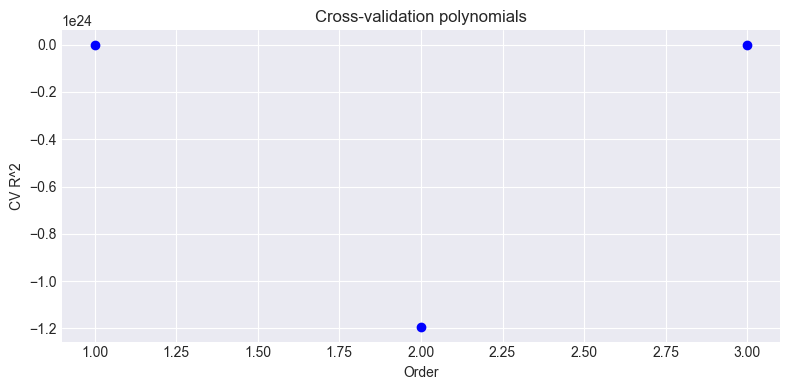

```python
fig, ax = plt.subplots(figsize=(8, 4))
plt.scatter(np.arange(1,4), avg_scores, c='b', label='data')
plt.axis('tight')
plt.title("Cross-validation polynomials")
ax.set_xlabel("Order")
ax.set_ylabel("CV R^2")
plt.tight_layout()
plt.show()
```

```python
# The best order with the maximum R^2?

max_value = max(avg_scores)
max_index = avg_scores.index(max_value)
print('The order with maximum R^2 is '+ str(max_index))
```

```
The order with maximum R^2 is 0
```

```python
# Show the best score with the training set and testing set

reg_poly2 = Pipeline([('stand', StandardScaler()),
                  ('poly', PolynomialFeatures(degree=1)),
                  ('linear', LinearRegression(fit_intercept=False))])

reg_poly2.fit(X_train, y_train)
poly_train_res = reg_poly2.score(X_train, y_train)
poly_val_res = reg_poly2.score(X_val, y_val)

print(str(poly_train_res))
print(str(poly_val_res))
```

```
0.1267244776781946
0.06668829406294585
```

# K Nearest Neighbors

cross validation

```python
from sklearn.neighbors import KNeighborsRegressor
from sklearn.model_selection import cross_val_score

K = np.arange(1,100)
cv_scores = []
sd_scores = []
# perform 5-fold cross validation on the  possible values for the radius (bandwidth)

for k in K:
    knn = KNeighborsRegressor(n_neighbors=k)
    scores = cross_val_score(knn, X_train_stand, y_train, cv=5)
    cv_scores.append(scores.mean())
    sd_scores.append(np.sqrt(scores.var())/np.sqrt(5))
```

plot

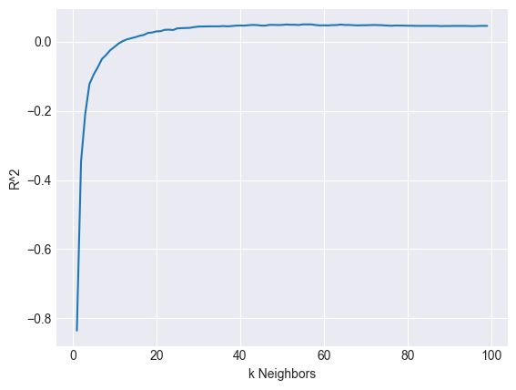

```
The best k is 55
```

```python
# Plotting the results

max_value = max(cv_scores)
max_index = cv_scores.index(max_value)

plt.plot(K, cv_scores)
plt.xlabel('k Neighbors')
plt.ylabel('R^2')

plt.show()
print('The best k is', K[max_index])
```

This plot is hard to read, so lets focus on values 40 to 60.

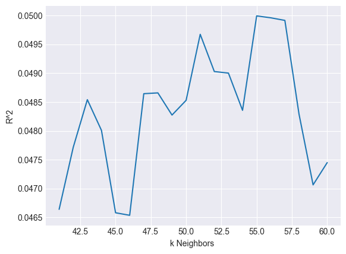

```
The best k is 55
The best validation score is 0.04999517164860523
```

```python
# let's zoom in to the nearest 50-60

plt.plot(K[40:60],cv_scores[40:60])
plt.xlabel('k Neighbors ')
plt.ylabel('R^2')

plt.show()
print('The best k is', K[max_index])
print('The best validation score is', max_value)
```

The best k is 55, with a validation score of 0.05. This is rather low. Let's see if the model in underfitted.

```python
knn = KNeighborsRegressor(n_neighbors=K[max_index])
knn.fit(X_train_stand, y_train)

# Calculate the score of the training set and the validation set
knn_train_res = knn.score(X_train_stand, y_train)
knn_val_res = knn.score(X_val_stand, y_val)

print(str(knn_train_res))
print(str(knn_val_res))
```

```
0.08709498885365285
0.04970808781522695
```

This is also not that high, so there indeed might be underfitting

# Radius Nearest Neighbors

cross validation from 17 to 28

```python
from sklearn.neighbors import RadiusNeighborsRegressor
from sklearn.model_selection import cross_val_score

Radius = np.linspace(17,28,40) # find peak R^2 from 40 calculated possibilities
cv_scores = []
sd_scores = []

# perform 5-fold cross validation on the 11 possible values for the radius (bandwith)
for k in Radius:
    Rnn = RadiusNeighborsRegressor(radius=k)
    scores = cross_val_score(Rnn, X_train_stand, y_train,  cv=5)
    cv_scores.append(scores.mean())
    sd_scores.append(np.sqrt(scores.var())/np.sqrt(5))
```

[output not shown]

[output cut: 49 more lines]

[output not shown]

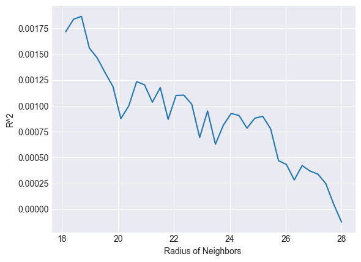

```
The best radius is 17.0
```

```python
max_value = max(cv_scores)
max_index = cv_scores.index(max_value)

plt.plot(Radius, cv_scores)
plt.xlabel('Radius of Neighbors ')
plt.ylabel('R^2')

plt.show()
print('The best radius is', Radius[max_index])
```

```python
max_value = max(cv_scores)
max_index = cv_scores.index(max_value)

print('The best radius is', Radius[max_index])

# retraining and testing
rnn_best = RadiusNeighborsRegressor(radius=Radius[max_index])
rnn_best.fit(X_train_stand, y_train)
print(rnn_best.score(X_train_stand, y_train))
print(max_value)
```

```
The best radius is 17.0
0.0046123172842437166
nan
```

# Tree based

## Decision trees

cross validation

```python
from sklearn.tree import DecisionTreeRegressor
from sklearn.model_selection import cross_val_score

depth = np.arange(1,50)    # This will give an array of numbers between 1 and 50
cv_scores = []
sd_scores = []

# perform 5-fold cross validation on the  possible values for the radius (bandwidth)
for d in depth:
    dec_tree = DecisionTreeRegressor(random_state=0, max_depth=d)
    scores = cross_val_score(dec_tree, X_train_stand, y_train, cv=5)
    cv_scores.append(scores.mean())
    sd_scores.append(np.sqrt(scores.var())/np.sqrt(5))
```

plot

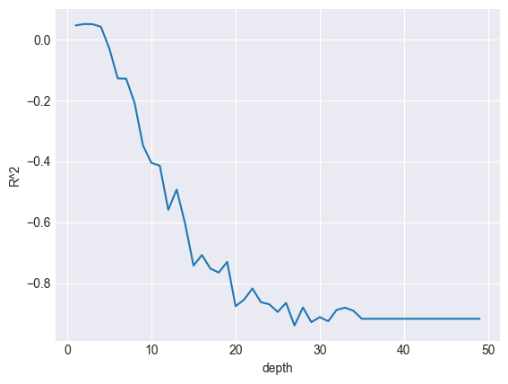

```
The best depth is 2
The best validation scorer is nan
```

```python
max_value_dt = max(cv_scores)
max_index_dt = cv_scores.index(max_value_dt)
# plot the results
plt.plot(depth, cv_scores)
plt.xlabel('depth')
plt.ylabel('R^2')

plt.show()
print('The best depth is', depth[max_index_dt])
print('The best validation scorer is', max_value)
```

Let's have a closer look

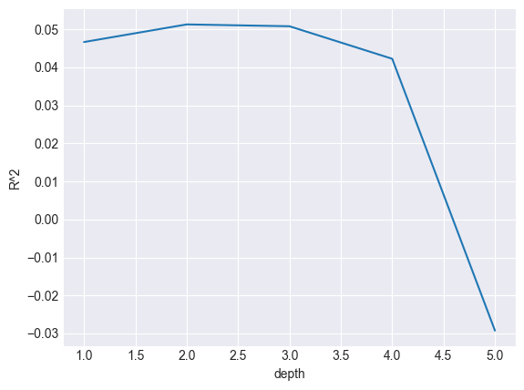

```
The best depth is 2
The best validation scorer is 0.051302900456260625
```

```python
max_value = max(cv_scores)
max_index = cv_scores.index(max_value)

plt.plot(depth[0:5], cv_scores[0:5])
plt.xlabel('depth')
plt.ylabel('R^2')

plt.show()
print('The best depth is', depth[max_index])
print('The best validation scorer is', max_value)
```

Retrain and test

```python
dec_tree = DecisionTreeRegressor(random_state=0, max_depth=depth[max_index_dt])
dec_tree.fit(X_train_stand, y_train)

dt_train_res = dec_tree.score(X_train_stand, y_train)# score of training dataset
dt_val_res = dec_tree.score(X_val_stand, y_val) # score of validation dataset

print(str(dt_train_res))
print(str(dt_val_res))
```

```
0.08455238997099335
0.04585482118765816
```

## Random Forest

### random search

```python
from sklearn.model_selection import RandomizedSearchCV
from sklearn.ensemble import RandomForestRegressor

criterion =['squared_error','absolute_error']
n_estimators = [int(x) for x in np.linspace(start = 100, stop = 500, num = 200)]
max_features = ['auto', 'sqrt', 'log2']
max_depth = [int(x) for x in np.linspace(1, 15, num = 15)]
min_samples_split = [int(x) for x in np.linspace(2, 15, num = 14)]
min_samples_leaf = [int(x) for x in np.linspace(1, 15, num = 15)]
max_leaf_nodes = [int(x) for x in np.linspace(10, 500, num = 490)]

# create the random grid to search for best hyperparameters
random_grid = {'criterion': criterion,
               'n_estimators': n_estimators,
               'max_features': max_features,
               'max_depth': max_depth,
               'min_samples_split': min_samples_split,
               'min_samples_leaf': min_samples_leaf,
               'max_leaf_nodes': max_leaf_nodes}

# then do cross-validatoin
rf = RandomForestRegressor()
rf_random = RandomizedSearchCV(estimator = rf, param_distributions = random_grid, n_iter = 100,
                               cv = 3, verbose=2, random_state=42, n_jobs=-1)
# n_jobs=-1 to run as many models  parallel as possible
rf_random.fit(X_train_stand, y_train)
```

```
Fitting 3 folds for each of 100 candidates, totalling 300 fits
```

```
RandomizedSearchCV(cv=3, estimator=RandomForestRegressor(), n_iter=100,
                   n_jobs=-1,
                   param_distributions={'criterion': ['squared_error',
                                                      'absolute_error'],
                                        'max_depth': [1, 2, 3, 4, 5, 6, 7, 8, 9,
                                                      10, 11, 12, 13, 14, 15],
                                        'max_features': ['auto', 'sqrt',
                                                         'log2'],
                                        'max_leaf_nodes': [10, 11, 12, 13, 14,
                                                           15, 16, 17, 18, 19,
                                                           20, 21, 22, 23, 24,
                                                           25, 26, 27, 28, 29,
                                                           30, 31, 32, 33, 34,
                                                           35, 36, 37, 38, 39, ...],
                                        'min_samples_leaf': [1, 2, 3, 4, 5, 6,
                                                             7, 8, 9, 10, 11,
                                                             12, 13, 14, 15],
                                        'min_samples_split': [2, 3, 4, 5, 6, 7,
                                                              8, 9, 10, 11, 12,
                                                              13, 14, 15],
                                        'n_estimators': [100, 102, 104, 106,
                                                         108, 110, 112, 114,
                                                         116, 118, 120, 122,
                                                         124, 126, 128, 130,
                                                         132, 134, 136, 138,
                                                         140, 142, 144, 146,
                                                         148, 150, 152, 154,
                                                         156, 158, ...]},
                   random_state=42, verbose=2)
```

Print out the training and validated $R^2$ for the best model from the random search

```python
print(rf_random.best_score_)

# retraining and testing
rf_train_res = rf_random.score(X_train_stand, y_train)
rf_val_res = rf_random.score(X_val_stand, y_val)

print(rf_train_res) #training data
print(rf_val_res) #validation data
```

```
0.09322201642437282
0.1620748656072466
0.06309749710559986
```

print out the parameters of the best model

```python
rf_random.best_params_
```

```
{'n_estimators': 341,
 'min_samples_split': 14,
 'min_samples_leaf': 15,
 'max_leaf_nodes': 224,
 'max_features': 'auto',
 'max_depth': 4,
 'criterion': 'squared_error'}
```

```python
out = pd.DataFrame(rf_random.cv_results_)
out.head()
```

|  | mean_fit_time | std_fit_time | mean_score_time | std_score_time | param_n_estimators | param_min_samples_split | param_min_samples_leaf | param_max_leaf_nodes | param_max_features | param_max_depth | param_criterion | params | split0_test_score | split1_test_score | split2_test_score | mean_test_score | std_test_score | rank_test_score |
| --- | --- | --- | --- | --- | --- | --- | --- | --- | --- | --- | --- | --- | --- | --- | --- | --- | --- | --- |
| 0 | 110.337274 | 2.232347 | 0.052667 | 0.008958 | 385 | 7 | 14 | 90 | auto | 12 | absolute_error | {'n_estimators': 385, 'min_samples_split': 7, ... | -0.139692 | -0.128069 | -0.194329 | -0.154030 | 0.028888 | 69 |
| 1 | 3.573385 | 0.445897 | 0.028669 | 0.002624 | 138 | 6 | 13 | 444 | sqrt | 6 | absolute_error | {'n_estimators': 138, 'min_samples_split': 6, ... | -0.209653 | -0.201352 | -0.246945 | -0.219317 | 0.019828 | 91 |
| 2 | 0.645998 | 0.081846 | 0.037000 | 0.002945 | 128 | 12 | 4 | 148 | log2 | 13 | squared_error | {'n_estimators': 128, 'min_samples_split': 12,... | 0.084982 | 0.081571 | 0.049697 | 0.072083 | 0.015891 | 21 |
| 3 | 88.549070 | 2.124094 | 0.058335 | 0.005794 | 457 | 7 | 15 | 213 | auto | 2 | absolute_error | {'n_estimators': 457, 'min_samples_split': 7, ... | -0.154925 | -0.137943 | -0.206606 | -0.166491 | 0.029200 | 76 |
| 4 | 7.211482 | 0.863112 | 0.043332 | 0.009740 | 274 | 12 | 8 | 191 | sqrt | 5 | absolute_error | {'n_estimators': 274, 'min_samples_split': 12,... | -0.207050 | -0.188296 | -0.238936 | -0.211428 | 0.020904 | 83 |

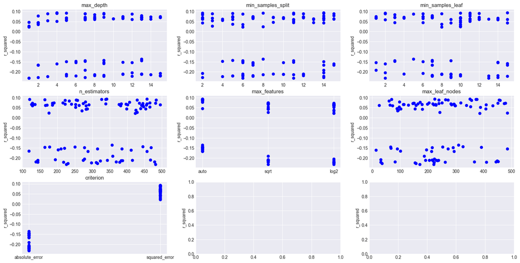

```python
xlabel_names = ['param_max_depth','param_min_samples_split','param_min_samples_leaf','param_n_estimators',
                'param_max_features', 'param_max_leaf_nodes', 'param_criterion']

fig, axs = plt.subplots(3,3, figsize=(20,10))
# plot the results
axs[0,0].scatter(out['param_max_depth'], out['mean_test_score'], c='blue');
axs[0,0].set_title('max_depth')

axs[0,1].scatter(out['param_min_samples_split'], out['mean_test_score'], c='blue');
axs[0,1].set_title('min_samples_split')

axs[0,2].scatter(out['param_min_samples_leaf'], out['mean_test_score'], c='blue');
axs[0,2].set_title('min_samples_leaf')

axs[1,0].scatter(out['param_n_estimators'], out['mean_test_score'], c='blue');
axs[1,0].set_title('n_estimators')

axs[1,1].scatter(out['param_max_features'], out['mean_test_score'], c='blue');
axs[1,1].set_title('max_features')

axs[1,2].scatter(out['param_max_leaf_nodes'], out['mean_test_score'], c='blue');
axs[1,2].set_title('max_leaf_nodes')

axs[2,0].scatter(out['param_criterion'], out['mean_test_score'], c='blue');
axs[2,0].set_title('criterion')

for ax in axs.flat:
    ax.set(ylabel='r_squared')
```

### grid search

```python
from sklearn.model_selection import GridSearchCV
from sklearn.ensemble import RandomForestRegressor

criterion =['squared_error']
n_estimators = [341] #see best params
max_features = ['auto'] #see best params
max_depth = [4] #see plot
min_samples_split = [14] #see plot
min_samples_leaf = [2, 15] #see plot
max_leaf_nodes = [224, 356] #see best params


# create the random grid to search for best hyperparameters
grid = {'criterion': criterion,
               'n_estimators': n_estimators,
               'max_features': max_features,
                'max_leaf_nodes': max_leaf_nodes,
               'max_depth': max_depth,
               'min_samples_split': min_samples_split,
               'min_samples_leaf': min_samples_leaf}

# then do cross-validation
rf = RandomForestRegressor()
rf_grid = GridSearchCV(estimator=rf, param_grid=grid, cv=5,verbose=2, n_jobs=-1)

# n_jobs=-1 to run as many models  parallel as possible
rf_grid.fit(X_train_stand, y_train)
```

```
Fitting 5 folds for each of 4 candidates, totalling 20 fits
```

```
GridSearchCV(cv=5, estimator=RandomForestRegressor(), n_jobs=-1,
             param_grid={'criterion': ['squared_error'], 'max_depth': [4],
                         'max_features': ['auto'], 'max_leaf_nodes': [224, 356],
                         'min_samples_leaf': [2, 15], 'min_samples_split': [14],
                         'n_estimators': [341]},
             verbose=2)
```

```python
rf_grid.best_params_
```

```
{'criterion': 'squared_error',
 'max_depth': 4,
 'max_features': 'auto',
 'max_leaf_nodes': 356,
 'min_samples_leaf': 15,
 'min_samples_split': 14,
 'n_estimators': 341}
```

```python
print(rf_random.best_score_)

rf_train_res = rf_random.score(X_train_stand, y_train)
rf_val_res = rf_random.score(X_val_stand, y_val)

print(rf_train_res) #training data
print(rf_val_res) #validation data
```

```
0.09322201642437282
0.1620748656072466
0.06309749710559986
```

```python
# Best params
params = rf_grid.best_params_
rf_gridBest = RandomForestRegressor(**params)
rf_gridBest.fit(X_train_stand, y_train)
```

```
RandomForestRegressor(max_depth=4, max_features='auto', max_leaf_nodes=356,
                      min_samples_leaf=15, min_samples_split=14,
                      n_estimators=341)
```

# whitening the black box (interpret results easier)

### feature importance

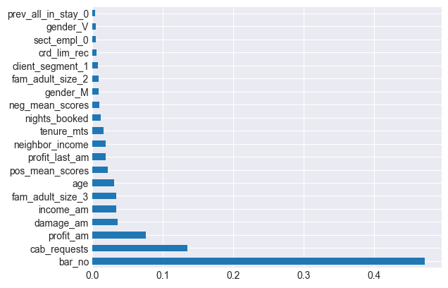

```python
# Plot the 20 most important params

from matplotlib import pyplot as plt

plt.figure()

feat_importances = pd.Series(rf_gridBest.feature_importances_, index=X_train.columns)
feat_importances.nlargest(20).plot(kind='barh')
plt.show()
```

### Influence of each feature

get predictions from random forest

```python
pred_train = rf_gridBest.predict(X_train_stand)
```

Perform one univariate linear regressions per feature on the predicted values!

```python
# Performing one univariate linear regression per feature on the predicted values.

from sklearn.linear_model import LinearRegression

# Creating a pandas DataFrame for the standardized training features
X = pd.DataFrame(X_train_stand)
X.columns = X_train.columns
predictors =  X_train.columns
# Standardizing the predicted values of the training set and reshaping to 2D
y = np.array((pred_train-pred_train.mean())/np.sqrt(pred_train.var())).reshape(-1, 1)

reg = LinearRegression().fit(X[[predictors[0]]], y)
beta = pd.Series(reg.coef_[0])
names = pd.Series(predictors[0])

# Performing a univariate linear regression on each feature
for i in np.arange(1,(X.shape[1])):
    reg = LinearRegression().fit(X[[predictors[i]]], y)
    beta_help = pd.Series(reg.coef_[0])
    names_help = pd.Series(predictors[i])
    beta = pd.concat([beta,beta_help], axis=0)
    names = pd.concat([names,names_help], axis=0)
# Combining the names and beta Series into a single DataFrame
betas = pd.concat([names,beta],axis=1)
betas
```

|  | 0 | 1 |
| --- | --- | --- |
| 0 | income_am | 0.164004 |
| 0 | profit_last_am | 0.116127 |
| 0 | profit_am | 0.250455 |
| 0 | damage_am | 0.257084 |
| 0 | crd_lim_rec | 0.297073 |
| ... | ... | ... |
| 0 | shop_use_Undefined | -0.350618 |
| 0 | retired_0 | 0.187826 |
| 0 | retired_1 | -0.187826 |
| 0 | gold_status_0 | -0.505134 |
| 0 | gold_status_1 | 0.505134 |

96 rows × 2 columns

# Gradient boosting machine

random search

```python
from sklearn.model_selection import RandomizedSearchCV
from sklearn.ensemble import GradientBoostingRegressor

criterion =['squared_error','absolute_error']
n_estimators = [int(x) for x in np.linspace(start = 100, stop = 500, num = 50)]
max_features = ['auto', 'sqrt', 'log2']
max_depth = [int(x) for x in np.linspace(1, 15, num = 15)]
min_samples_split = [int(x) for x in np.linspace(2, 15, num = 14)]
min_samples_leaf = [int(x) for x in np.linspace(1, 15, num = 15)]
max_leaf_nodes = [int(x) for x in np.linspace(10, 500, num = 50)]
loss = ['ls','lad','huber','quantile'] # see pwp
learning_rate = [round(x,5) for x in np.linspace(0.1, 1, num = 10)] # see pwp default

# create the random grid to search for best hyperparameters
random_grid = {'criterion': criterion,
               'n_estimators': n_estimators,
               'max_features': max_features,
               'max_depth': max_depth,
               'min_samples_split': min_samples_split,
               'min_samples_leaf': min_samples_leaf,
               'max_leaf_nodes': max_leaf_nodes,
               'loss': loss,
               'learning_rate': learning_rate}

# then do cross-validation
gbm = GradientBoostingRegressor()
gbm_random = RandomizedSearchCV(estimator = gbm, param_distributions = random_grid, n_iter=100, cv=3, verbose=2, random_state=42, n_jobs=-1)

gbm_random.fit(X_train_stand, y_train)
```

```
Fitting 3 folds for each of 100 candidates, totalling 300 fits
```

[output not shown]

[output cut: 178 more lines]

[output not shown]

```
RandomizedSearchCV(cv=3, estimator=GradientBoostingRegressor(), n_iter=100,
                   n_jobs=-1,
                   param_distributions={'criterion': ['squared_error',
                                                      'absolute_error'],
                                        'learning_rate': [0.1, 0.2, 0.3, 0.4,
                                                          0.5, 0.6, 0.7, 0.8,
                                                          0.9, 1.0],
                                        'loss': ['ls', 'lad', 'huber',
                                                 'quantile'],
                                        'max_depth': [1, 2, 3, 4, 5, 6, 7, 8, 9,
                                                      10, 11, 12, 13, 14, 15],
                                        'max_features': ['auto', 'sqrt',
                                                         'log2'],
                                        'max_leaf_node...
                                                           150, 160, 170, 180,
                                                           190, 200, 210, 220,
                                                           230, 240, 250, 260,
                                                           270, 280, 290, 300, ...],
                                        'min_samples_leaf': [1, 2, 3, 4, 5, 6,
                                                             7, 8, 9, 10, 11,
                                                             12, 13, 14, 15],
                                        'min_samples_split': [2, 3, 4, 5, 6, 7,
                                                              8, 9, 10, 11, 12,
                                                              13, 14, 15],
                                        'n_estimators': [100, 108, 116, 124,
                                                         132, 140, 148, 157,
                                                         165, 173, 181, 189,
                                                         197, 206, 214, 222,
                                                         230, 238, 246, 255,
                                                         263, 271, 279, 287,
                                                         295, 304, 312, 320,
                                                         328, 336, ...]},
                   random_state=42, verbose=2)
```

Print out the validated $R^2$ for the best model from the random search

```python
print(gbm_random.best_score_)


print(gbm_random.score(X_train_stand, y_train)) #training data
print(gbm_random.score(X_val_stand, y_val)) #validation data
```

```
0.0276167877813502
0.6825051707796753
0.009327147517075751
```

```python
gbm_random.best_params_
```

```
{'n_estimators': 124,
 'min_samples_split': 11,
 'min_samples_leaf': 14,
 'max_leaf_nodes': 310,
 'max_features': 'sqrt',
 'max_depth': 14,
 'loss': 'huber',
 'learning_rate': 0.1,
 'criterion': 'squared_error'}
```

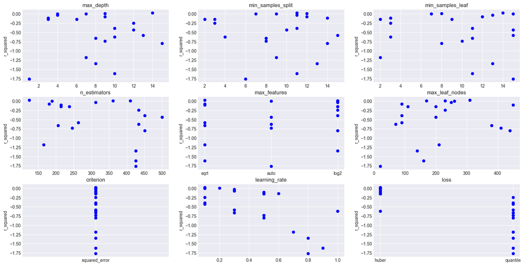

```python
# plotting out the results of the hyperparameters

out = pd.DataFrame(gbm_random.cv_results_)

xlabel_names = ['param_max_depth','param_min_samples_split','param_min_samples_leaf','param_n_estimators',
                'param_max_features', 'param_max_leaf_nodes', 'param_criterion']

fig, axs = plt.subplots(3,3, figsize=(20,10))

axs[0,0].scatter(out['param_max_depth'], out['mean_test_score'], c='blue')
axs[0,0].set_title('max_depth')

axs[0,1].scatter(out['param_min_samples_split'], out['mean_test_score'], c='blue')
axs[0,1].set_title('min_samples_split')

axs[0,2].scatter(out['param_min_samples_leaf'], out['mean_test_score'], c='blue')
axs[0,2].set_title('min_samples_leaf')

axs[1,0].scatter(out['param_n_estimators'], out['mean_test_score'], c='blue')
axs[1,0].set_title('n_estimators')

axs[1,1].scatter(out['param_max_features'], out['mean_test_score'], c='blue')
axs[1,1].set_title('max_features')

axs[1,2].scatter(out['param_max_leaf_nodes'], out['mean_test_score'], c='blue')
axs[1,2].set_title('max_leaf_nodes')

axs[2,0].scatter(out['param_criterion'], out['mean_test_score'], c='blue')
axs[2,0].set_title('criterion')

axs[2,1].scatter(out['param_learning_rate'], out['mean_test_score'], c='blue')
axs[2,1].set_title('learning_rate')

axs[2,2].scatter(out['param_loss'], out['mean_test_score'], c='blue')
axs[2,2].set_title('loss')


for ax in axs.flat: ax.set(ylabel='r_squared')
```

lets tune the hyperparameters of the model a bit further with grid search